# SR 4

2022-09-30

Install these if you haven’t already.

```r
install.packages("tidybayes")
devtools::install_github("mjskay/tidybayes.rethinking")
```

```r
library(tidyverse)
library(rethinking)
library(tidybayes)
library(tidybayes.rethinking)
library(ggthemes)
theme_set(theme_pander())
```

## 4.3 Gaussian model of height

Get the data and limit it to adults.

```r
data(Howell1)
d <- Howell1 |>
  filter(age >= 18)
```

I’m OK with you using `precis()` to summarize the raw data. It’s pretty nice, actually.

```r
precis(d)
```

```
##             mean         sd     5.5%     94.5%       histogram
## height 154.59709  7.7423321 142.8750 167.00500       ▁▃▇▇▅▇▂▁▁
## weight  44.99049  6.4567081  35.1375  55.76588         ▁▅▇▇▃▂▁
## age     41.13849 15.9678551  20.0000  70.00000 ▂▅▇▅▃▇▃▃▂▂▂▁▁▁▁
## male     0.46875  0.4997328   0.0000   1.00000      ▇▁▁▁▁▁▁▁▁▇
```

Let’s look at a “quick” version of `ggplot()` to get a sense of the data.

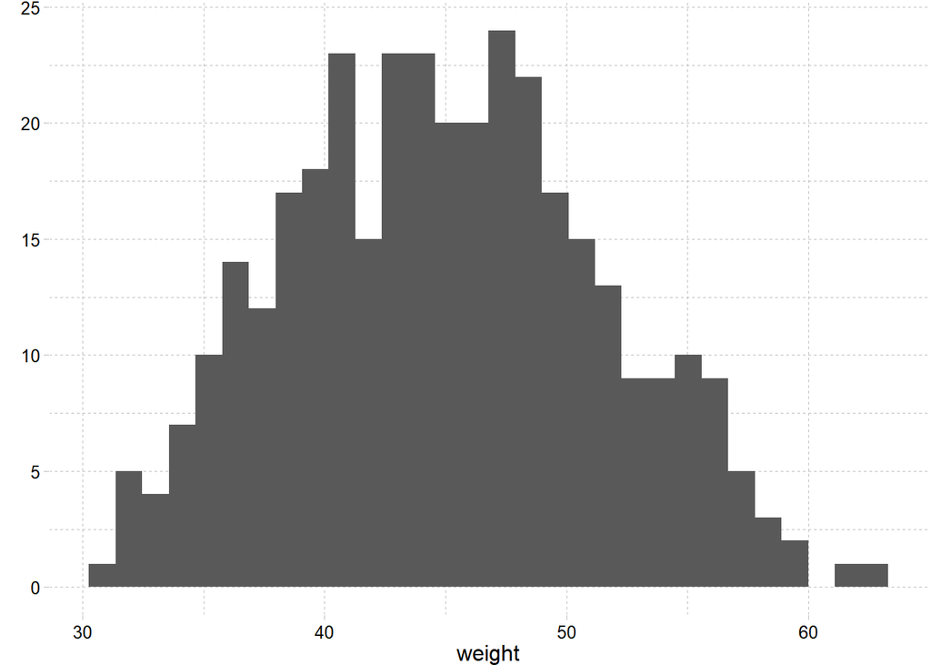

```r
qplot(weight, data = d)
```

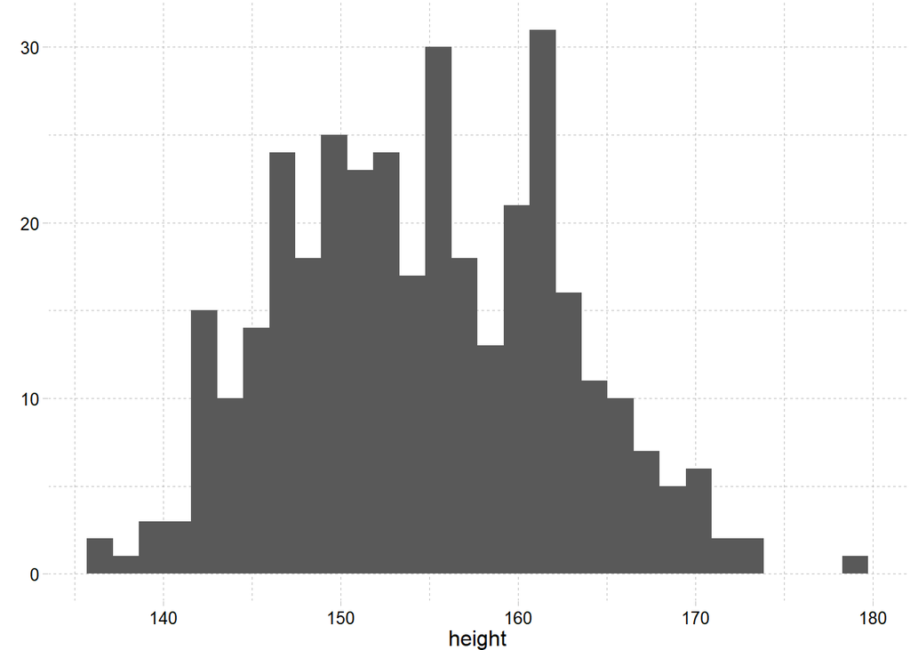

```r
qplot(height, data = d)
```

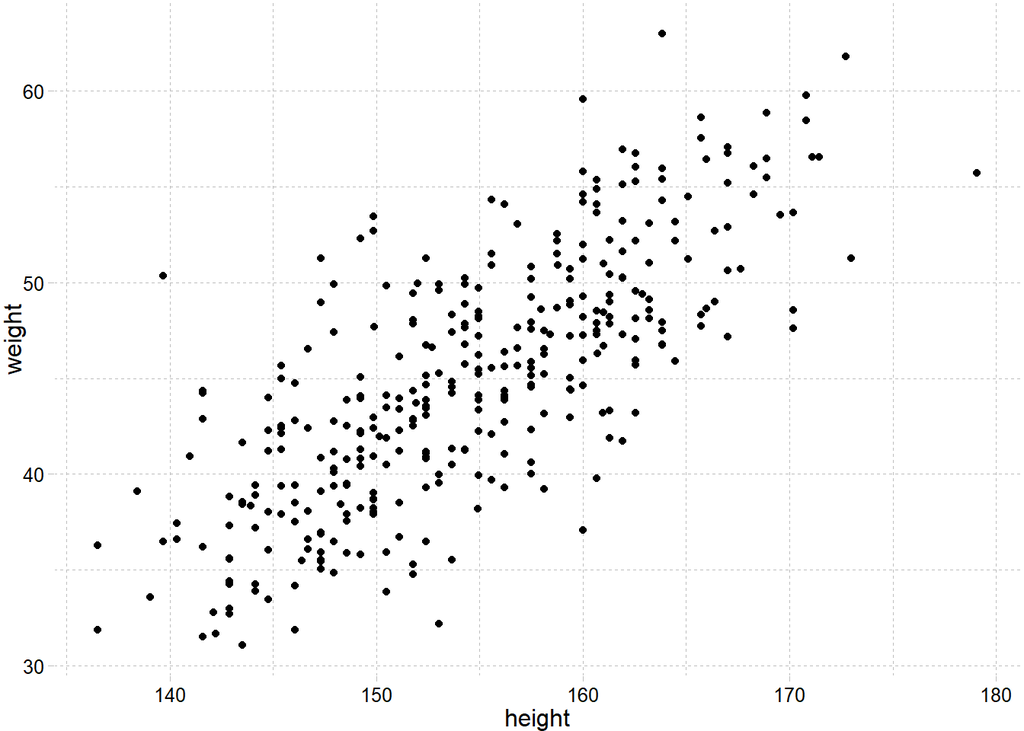

```r
qplot(height, weight, data = d)
```

```r
# how many fake lines?
nsims <- 12

# simulate some lines (and sigmas)
set.seed(0929)
sims1 <- tibble(
  id = 1:nsims,
  a = rnorm(nsims, mean = 0, sd = 1),
  b = rnorm(nsims, mean = 0, sd = 1),
  sigma = runif(nsims, min = 0, max = 1)
)

# here are the fake lines (and sigmas)
head(sims1, nsims)
```

```
## # A tibble: 12 × 4
##       id       a       b  sigma
##    <int>   <dbl>   <dbl>  <dbl>
##  1     1  0.102   0.779  0.909
##  2     2 -0.944  -1.17   0.360
##  3     3 -3.20    0.239  0.136
##  4     4  1.15    2.30   0.829
##  5     5  0.399   1.54   0.860
##  6     6 -0.728  -0.0604 0.642
##  7     7  0.806  -1.08   0.263
##  8     8 -1.03    0.507  0.0665
##  9     9  0.333  -0.141  0.0258
## 10    10 -0.0695 -1.46   0.0114
## 11    11 -0.558  -0.299  0.487
## 12    12  0.243   1.78   0.319
```

We can plot these lines.

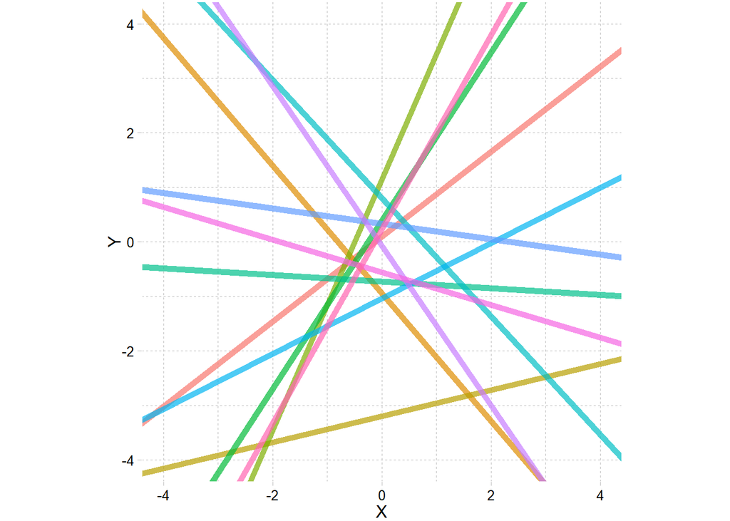

```r
ggplot(sims1) +
  geom_abline(
    aes(color = factor(id),
        slope = b,
        intercept = a),
    size = 2,
    alpha = .7) +
  xlim(-4,4) +
  ylim(-4,4) +
  labs(x = "X",
       y = "Y") +
  theme(legend.position = "none") +
  theme(aspect.ratio = 1)
```

These are lines that are plausible given our priors. Note, however, that we didn’t use sigma. That’s because `a` and `b` define the line of expectation and `sigma` defines the spread around that expectation.

We could make some fake data that corresponds to each of these.

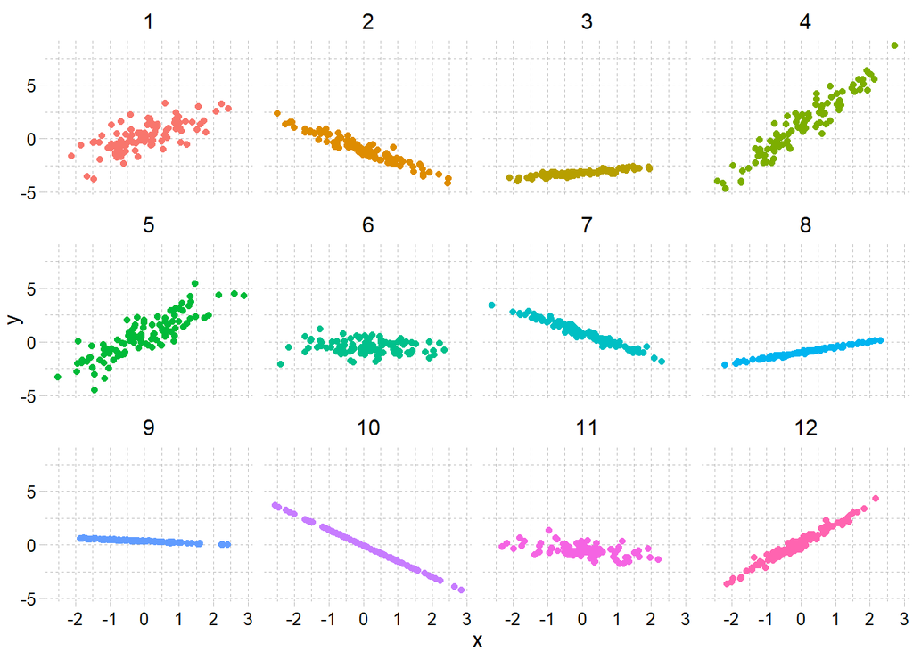

```r
# how many fake observations per made up line?
obs_per_sim <- 100

# create the fake data
sims1_data <- sims1 |>
  uncount(100) |>
  mutate(x = rnorm(n = nsims * obs_per_sim,
                   mean = 0,
                   sd = 1),
         y = rnorm(n = nsims * obs_per_sim,
                   mean = a + b*x,
                   sd = sigma ))

# faceted plot
ggplot(sims1_data,
       aes(x = x,
           y = y,
           color = factor(id))) +
  geom_point() +
  facet_wrap(~ id) +
  theme(legend.position = "none")
```

Let’s go back to height and weight.

Here’s the model:

$$\begin{aligned}
weight_i &\sim \text{Normal}(\mu_i, \sigma) \\
\mu_i &= \alpha + \beta \: height_i \\
\alpha &\sim \text{Normal}(?,?) \\
\beta &\sim \text{Normal}(?,?) \\
\sigma &\sim \text{Uniform}(0,?)
\end{aligned}$$

McElreath talks about some variable transformations in the lecture. Here are some possibilities.

- We could leave height as it is. In this case, it would mean that $\alpha$ must be equal to zero since something with zero height must also have zero weight!
- We could “mean center” height by replacing $height_i$ with $(height_i - \overline{height})$. This would mean $\alpha$ now refers to the **mean weight** in the group.
- An option he doesn’t discuss is that we could mean center both variables. This would force $\alpha$ to be zero because someone of average height must also be expected to be of average weight. (Prove this to yourself if you don’t believe it!) This has the advantage of making us only have to come up with a prior for the slope ($\beta$) and the scale parameter ($\sigma$)

Let’s center both variables and use a lognormal prior for the slope since we know it has to be positive. We will also use a ridiculously wide prior for sigma. Instead of writing out the centering expressions, I will put a * on the variable to indicate that its mean has been subtracted away.

$$\begin{aligned}
weight^*_i &\sim \text{Normal}(\mu_i, \sigma) \\
\mu_i &= \alpha + \beta \: height^*_i \\
\alpha &= 0 \\
\beta &\sim \text{Lognormal}(0,1) \\
\sigma &\sim \text{Uniform}(0,30)
\end{aligned}$$

We can do prior predictive simulations of this as above.

```r
# how many fake lines?
nsims <- 12

# simulate some lines (and sigmas)
set.seed(0929)
sims2 <- tibble(
  id = 1:nsims,
  a = rep(0, nsims),
  b = rlnorm(nsims, meanlog = 0, sdlog = 1),
  sigma = runif(nsims, min = 0, max = 30)
)

# here are the fake lines (and sigmas)
head(sims2, nsims)
```

```
## # A tibble: 12 × 4
##       id     a      b sigma
##    <int> <dbl>  <dbl> <dbl>
##  1     1     0 1.11   23.5
##  2     2     0 0.389   1.42
##  3     3     0 0.0408  3.62
##  4     4     0 3.17    7.68
##  5     5     0 1.49   17.8
##  6     6     0 0.483  19.0
##  7     7     0 2.24   29.7
##  8     8     0 0.357  19.2
##  9     9     0 1.40   28.2
## 10    10     0 0.933   1.75
## 11    11     0 0.572  14.3
## 12    12     0 1.28   19.6
```

We can plot these lines.

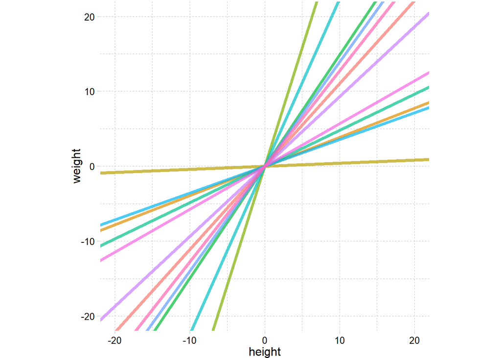

```r
ggplot(sims2) +
  geom_abline(
    aes(color = factor(id),
        slope = b,
        intercept = a),
    size = 1.5,
    alpha = .7) +
  xlim(-20,20) +
  ylim(-20,20) +
  labs(x = "height",
       y = "weight") +
  theme(legend.position = "none") +
  theme(aspect.ratio = 1)
```

Again, these are lines that are plausible given our priors. Again, however, that we didn’t use sigma. That’s because `a` and `b` define the line of expectation and `sigma` defines the spread around that expectation. Let’s make some fake data again.

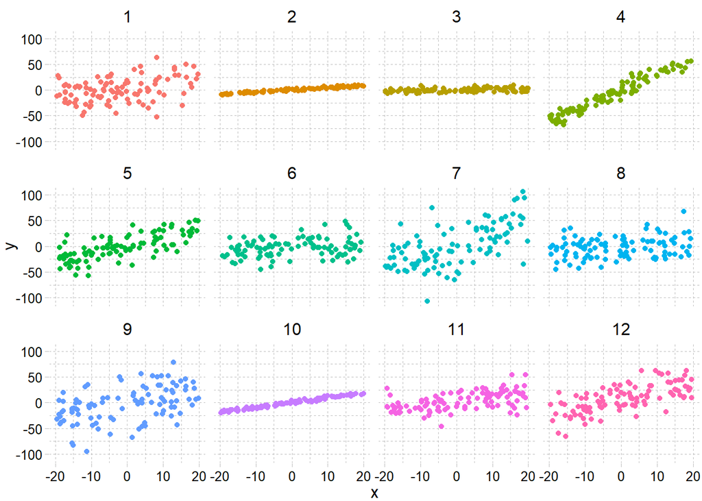

```r
# how many fake observations per made up line?
obs_per_sim <- 100

# create the fake data
sims2_data <- sims2 |>
  uncount(100) |>
  mutate(x = runif(n = nsims * obs_per_sim,
                   min = -20,
                   max =  20),
         y = rnorm(n = nsims * obs_per_sim,
                   mean = a + b*x,
                   sd = sigma ))

# faceted plot
ggplot(sims2_data,
       aes(x = x,
           y = y,
           color = factor(id))) +
  geom_point() +
  facet_wrap(~ id) +
  theme(legend.position = "none")
```

OK this isn’t insane. So let’s move on to estimating the models using `quap()`. For this week, you *must* use `quap()`. Later on I might let you use other things but not this week!

The first thing is to make the centered versions of the variables.

```r
d <- d |>
  mutate(cweight = weight - mean(d$weight),
         cheight = height - mean(d$height))
```

Then we set up the formula. Note that we can’t tell it that `a` is exactly zero. (I’ve tried, anyway.) So we can just omit it from the expression. This is allowed if we’ve centered both variables.

```r
flist <- alist(
  cweight ~ dnorm(mu, sigma),
  mu <- b*cheight,
  b ~ dlnorm(0, 1),
  sigma ~ dunif(0, 30)
)
```

How we can estimate the model.

```r
m1 <- quap(flist,
           data = d)
```

Let’s look at a summary of the results.

```r
precis(m1)
```

```
##            mean         sd      5.5%     94.5%
## b     0.6286962 0.02914516 0.5821166 0.6752758
## sigma 4.2296821 0.15941250 3.9749102 4.4844541
```

This is fine and all, but we are supposed to work with the whole posterior distribution. So let’s get some samples using the `tidy_draws()` function. This comes from the **tidybayes.rethinking** addition to the **tidybayes** package. The code to install these is above if you haven’t done it.

```r
draws <- tidy_draws(m1, n = 100)
head(draws)
```

```
## # A tibble: 6 × 5
##   .chain .iteration .draw     b sigma
##    <int>      <int> <int> <dbl> <dbl>
## 1     NA         NA     1 0.677  4.34
## 2     NA         NA     2 0.619  4.18
## 3     NA         NA     3 0.654  4.07
## 4     NA         NA     4 0.624  4.20
## 5     NA         NA     5 0.597  4.28
## 6     NA         NA     6 0.607  4.09
```

This is the density plot of `b`.

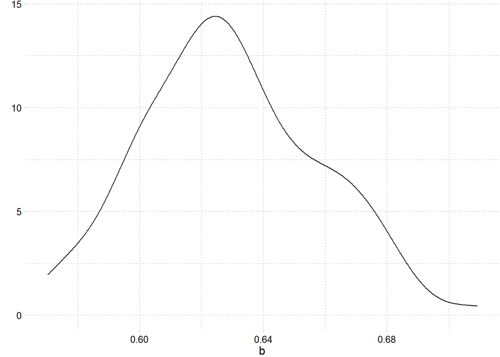

```r
qplot(b,
      data = draws,
      geom = "density")
```

Let’s plot the line along with the original data. I’m going to keep this graph so we can add to it later.

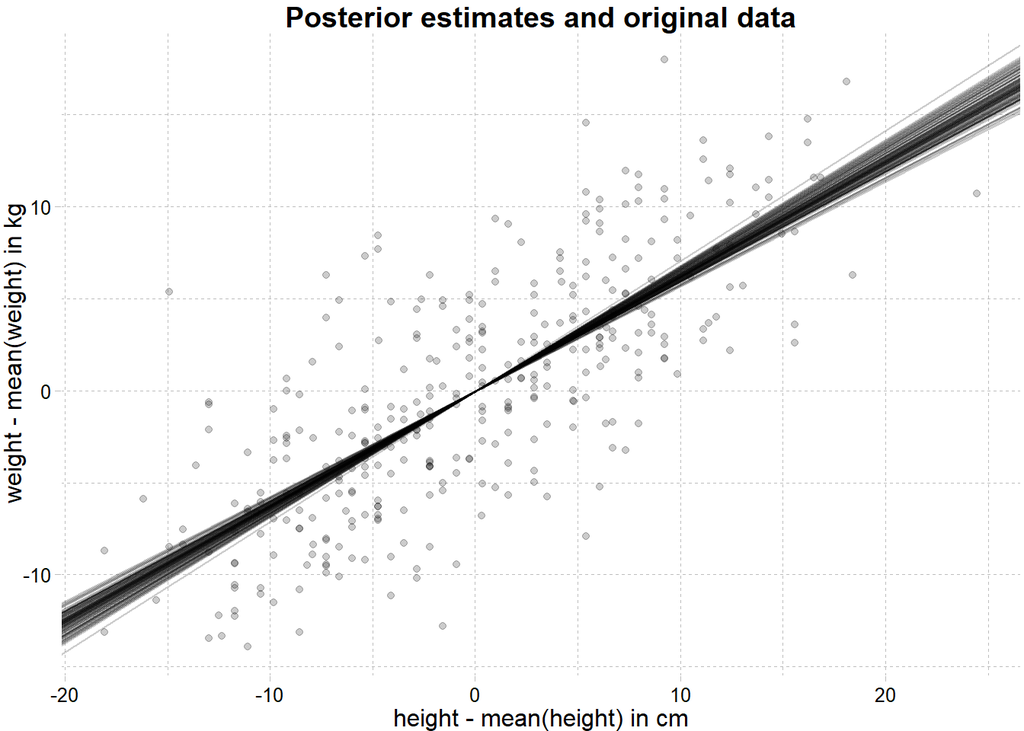

```r
p <- ggplot(draws) +
  geom_abline(aes(intercept = 0,
                  slope = b),
              alpha = .2) +
  geom_point(
    data = d,
    mapping = aes(x = cheight,
                  y = cweight),
    alpha = .2) +
  labs(x = "height - mean(height) in cm",
       y = "weight - mean(weight) in kg",
       title = "Posterior estimates and original data")

p
```

This looks pretty good but it only tells us about the expected values. What about adding sigma to these?

The `predicted_draws()` function will get `draws` number of predictions for every actual data point based on draws of the linear predictor plus sigma. The default is 5000 but we’ll use 1000 to speed things up a bit.

```r
ppsims <- predicted_draws(m1,
                          newdata = d,
                          draws = 1000)
head(ppsims, 20)
```

```
## # A tibble: 20 × 9
## # Groups:   height, weight, age, male, cweight, cheight, .row [1]
##    height weight   age  male cweight cheight  .row .draw .prediction
##     <dbl>  <dbl> <dbl> <int>   <dbl>   <dbl> <int> <int>       <dbl>
##  1   152.   47.8    63     1    2.84   -2.83     1     1     -0.880
##  2   152.   47.8    63     1    2.84   -2.83     1     2      4.41
##  3   152.   47.8    63     1    2.84   -2.83     1     3     -5.02
##  4   152.   47.8    63     1    2.84   -2.83     1     4      0.650
##  5   152.   47.8    63     1    2.84   -2.83     1     5     -7.06
##  6   152.   47.8    63     1    2.84   -2.83     1     6      0.506
##  7   152.   47.8    63     1    2.84   -2.83     1     7      0.103
##  8   152.   47.8    63     1    2.84   -2.83     1     8      2.33
##  9   152.   47.8    63     1    2.84   -2.83     1     9     10.0
## 10   152.   47.8    63     1    2.84   -2.83     1    10     -5.91
## 11   152.   47.8    63     1    2.84   -2.83     1    11      2.24
## 12   152.   47.8    63     1    2.84   -2.83     1    12     -3.01
## 13   152.   47.8    63     1    2.84   -2.83     1    13     -2.97
## 14   152.   47.8    63     1    2.84   -2.83     1    14     -0.0443
## 15   152.   47.8    63     1    2.84   -2.83     1    15      0.115
## 16   152.   47.8    63     1    2.84   -2.83     1    16     -0.388
## 17   152.   47.8    63     1    2.84   -2.83     1    17     -5.14
## 18   152.   47.8    63     1    2.84   -2.83     1    18     -0.936
## 19   152.   47.8    63     1    2.84   -2.83     1    19     -3.81
## 20   152.   47.8    63     1    2.84   -2.83     1    20     -2.48
```

I can use `HPDI()` from **rethinking** to get the upper and lower bounds of the 89% interval for each case.

```r
ppsims <- ppsims |>
  group_by(.row) |>
  mutate(lo_bound = HPDI(.prediction)[1],
         up_bound = HPDI(.prediction)[2])
```

Now we add these to the plot we already have.

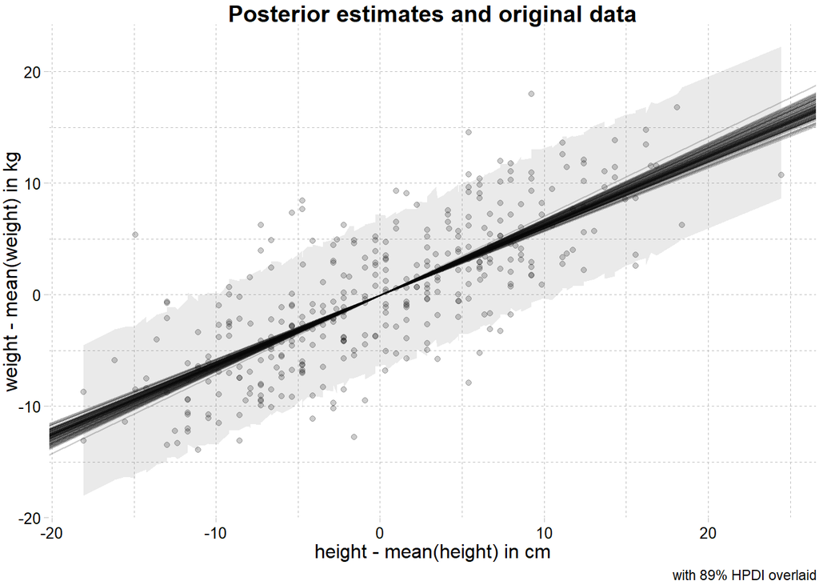

```r
p + geom_ribbon(data = ppsims,
                mapping = aes(
                  x = cheight,
                  ymax = up_bound,
                  ymin = lo_bound),
                alpha = .1) +
  labs(caption = "with 89% HPDI overlaid")
```

If we just want the ribbon, we can calculate the HDPIs on “fake” data that just gives a few values of `cheight`. This will speed things up and make it look less jagged.

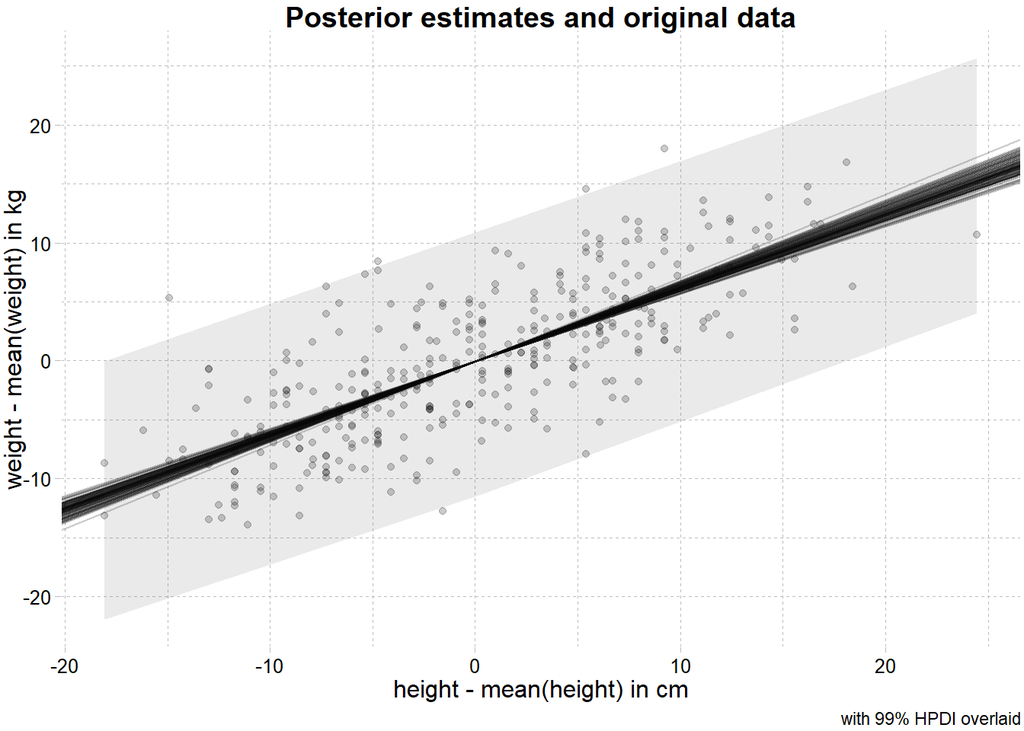

```r
some_cheights <- tibble(
  cheight = c(min(d$cheight), mean(d$cheight), max(d$cheight))
)

ppsims2 <- predicted_draws(m1,
                           newdata = some_cheights,
                           draws = 5000) |>
  group_by(.row) |>
  mutate(lo_bound = HPDI(.prediction, .99)[1], # just did 99% interval to change things up
         up_bound = HPDI(.prediction, .99)[2]) # ditto

p + geom_ribbon(data = ppsims2,
                mapping = aes(
                  x = cheight,
                  ymax = up_bound,
                  ymin = lo_bound),
                alpha = .1) +
  labs(caption = "with 99% HPDI overlaid")
```

## without centering the outcome

Let’s make the model

```r
flist2 <- alist(
  weight ~ dnorm(mu, sigma),
  mu <- a + b*cheight,
  a ~ dnorm(165, 40),
  b ~ dlnorm(0, 1),
  sigma ~ dunif(0, 30)
)
```

How we can estimate the model.

```r
m2 <- quap(flist2,
           data = d)
```

Look at results summary.

```r
precis(m2)
```

```
##             mean         sd       5.5%      94.5%
## a     44.9942976 0.22543940 44.6340019 45.3545933
## b      0.6286963 0.02914516  0.5821167  0.6752759
## sigma  4.2296819 0.15941251  3.9749099  4.4844539
```

Use `tidy_draws()` instead of `rethinking::link()`.

```r
draws2 <- tidy_draws(m2, n = 1000)
```

Draw the “bowtie” of model predictions. This will be a little sluggish because we’re drawing 1000 lines.

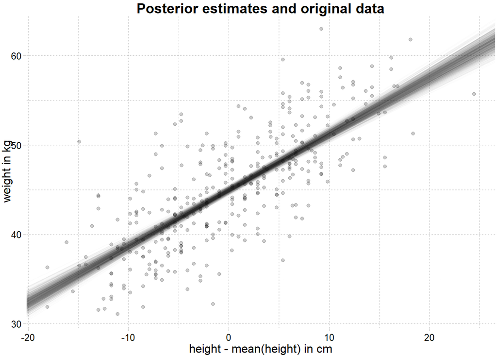

```r
p2 <- ggplot(draws2) +
  geom_abline(aes(intercept = a,
                  slope = b),
    alpha = .01) +
  geom_point(
    data = d,
    mapping = aes(x = cheight,
                  y = weight),
    alpha = .2) +
  labs(x = "height - mean(height) in cm",
       y = "weight in kg",
       title = "Posterior estimates and original data")

p2
```

Now we can use `predicted_draws()` instead of `rethinking::sim()`. Unlike what I did above, you can use the `post` argument to reuse the draws you’ve already drawn above using `tidy_draws()`. This matches more closely the *Rethinking* workflow.

```r
some_cheights <- tibble(
  cheight = c(min(d$cheight), mean(d$cheight), max(d$cheight))
)

sims2 <- predicted_draws(m2,
                         post = draws2,               # this parallels RM's link-to-sim workflow
                         newdata = some_cheights)
```

Now we can add the HPDI upper and lower bounds and plot, as before.

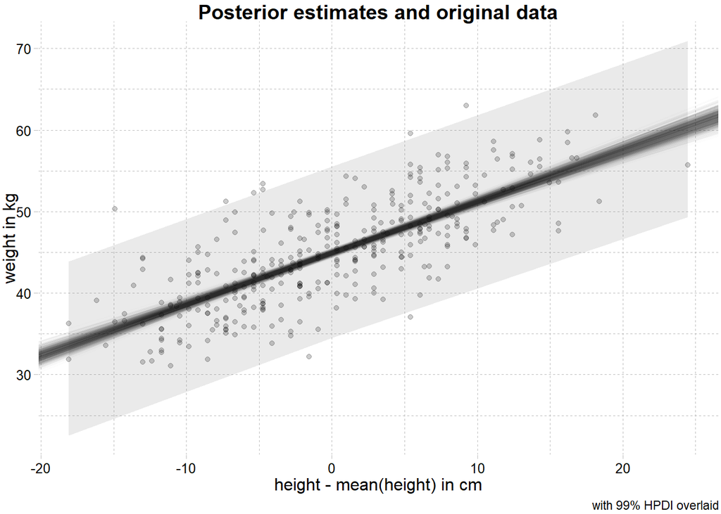

```r
sims2 <- sims2 |>
  group_by(.row) |>
  mutate(lo_bound = HPDI(.prediction, .99)[1], # just did 99% interval to change things up
         up_bound = HPDI(.prediction, .99)[2]) # ditto

p2 + geom_ribbon(data = sims2,
                mapping = aes(
                  x = cheight,
                  ymax = up_bound,
                  ymin = lo_bound),
                alpha = .1) +
  labs(caption = "with 99% HPDI overlaid")
```